# Functional enrichment of species-specific gene families in *Trypodendron lineatum*

Response to Reviewer 1, comment #4 (lines 446-448)

Author

Montes-Ortiz et al.

Published

April 24, 2026

# Aim

Functional enrichment analysis (GO + Pfam domains) of the species-specific gene families of *T. lineatum* identified by OrthoFinder.

**Definition of species-specific:** orthogroups where only *T. lineatum* has genes assigned (all other species empty). This excludes singletons (genes in `Orthogroups_UnassignedGenes.tsv`) and captures expanded gene families exclusive to the *T. lineatum* lineage relative to the 8 species compared.

> **Note on namespace conflicts.** Loading `topGO` pulls in `AnnotationDbi`, `IRanges` and `Biobase`, which mask several base/tidyverse functions (`select`, `filter`, `setdiff`, `intersect`, …). Throughout this script we use explicit `package::function` prefixes so the code runs correctly in a clean R session, independently of the order in which libraries are loaded.

# 1. Setup

```r
# ---- Installation (uncomment only the first time) ----
# install.packages(c("BiocManager", "tidyverse", "data.table",
#                    "ggplot2", "scales"))
# BiocManager::install(c("topGO", "Rgraphviz"))

suppressPackageStartupMessages({
  library(tidyverse)
  library(data.table)
  library(topGO)
  library(scales)
})

set.seed(42)

out_dir <- file.path("results", "enrichment_species_specific")
dir.create(out_dir, recursive = TRUE, showWarnings = FALSE)
```

# 2. Parameters

```r
# Update these paths to wherever your files live
interpro_tsv    <- "Tlin_interpro.tsv"
orthogroups_tsv <- "Orthogroups.tsv"

# EXACT name of the T. lineatum column in Orthogroups.tsv
target_species  <- "Fix_Trypodendron_lineatum"

# Thresholds
fdr_threshold   <- 0.05
min_node_size   <- 5    # topGO: minimum genes annotated per GO term
min_pfam_count  <- 2    # Pfam: domains with at least N genes to be tested
```

# 3. Parsing InterProScan

InterProScan TSV with `--goterms`. The file has 13 or 14 columns depending on the row (column 14 = GO terms when there is an InterPro match; absent otherwise). We use `data.table::fread` for efficient, memory-safe parsing of the ragged TSV.

```r
ipr_cols <- c("protein_id", "md5", "length", "analysis",
              "sig_acc", "sig_desc", "start", "end",
              "score", "status", "date",
              "ipr_acc", "ipr_desc", "go_terms", "pathways")

ipr_dt <- data.table::fread(interpro_tsv, sep = "\t", header = FALSE,
                            fill = TRUE, na.strings = c("", "NA", "-"),
                            colClasses = "character", quote = "")

data.table::setnames(ipr_dt, old = names(ipr_dt),
                     new = ipr_cols[seq_len(ncol(ipr_dt))])

ipr <- tibble::as_tibble(ipr_dt)
rm(ipr_dt); invisible(gc())

cat("Unique proteins in IPS:", dplyr::n_distinct(ipr$protein_id), "\n")
```

```
Unique proteins in IPS: 10512
```

```r
cat("Analyses present:      ", paste(unique(ipr$analysis), collapse = ", "), "\n")
```

```
Analyses present:       PANTHER, Pfam
```

```r
cat("Total rows:            ", nrow(ipr), "\n")
```

```
Total rows:             40119
```

## 3.1 gene → GO mapping

```r
gene2go_df <- ipr %>%
  dplyr::filter(!is.na(go_terms)) %>%
  dplyr::select(protein_id, go_terms) %>%
  tidyr::separate_rows(go_terms, sep = "\\|") %>%
  dplyr::mutate(go_terms = stringr::str_extract(go_terms, "GO:\\d{7}")) %>%
  dplyr::filter(!is.na(go_terms)) %>%
  dplyr::distinct()

# Named list for topGO: gene -> vector of GO IDs
gene2GO <- split(gene2go_df$go_terms, gene2go_df$protein_id)

cat("Genes with at least one GO:  ", length(gene2GO), "\n")
```

```
Genes with at least one GO:   6703
```

```r
cat("Total gene-GO assignments:   ", nrow(gene2go_df), "\n")
```

```
Total gene-GO assignments:    15520
```

## 3.2 gene → Pfam mapping

```r
gene2pfam <- ipr %>%
  dplyr::filter(analysis == "Pfam") %>%
  dplyr::select(protein_id, sig_acc, sig_desc) %>%
  dplyr::distinct()

cat("Genes with at least one Pfam:", dplyr::n_distinct(gene2pfam$protein_id), "\n")
```

```
Genes with at least one Pfam: 9503
```

```r
cat("Unique Pfam domains:         ", dplyr::n_distinct(gene2pfam$sig_acc), "\n")
```

```
Unique Pfam domains:          4456
```

# 4. Identifying species-specific orthogroups

```r
og <- readr::read_tsv(orthogroups_tsv, col_types = readr::cols(.default = "c"))

stopifnot(target_species %in% colnames(og))

other_species <- base::setdiff(colnames(og), c("Orthogroup", target_species))

og_specific <- og %>%
  dplyr::filter(!is.na(.data[[target_species]]) & .data[[target_species]] != "") %>%
  dplyr::filter(dplyr::if_all(dplyr::all_of(other_species), ~ is.na(.) | . == ""))

cat("Species-specific orthogroups:", nrow(og_specific), "\n")
```

```
Species-specific orthogroups: 73
```

```r
specific_genes <- og_specific %>%
  dplyr::pull(!!target_species) %>%
  stringr::str_split(",\\s*") %>%
  unlist() %>%
  stringr::str_trim() %>%
  purrr::discard(~ .x == "") %>%
  unique()

cat("Genes in species-specific orthogroups:", length(specific_genes), "\n")
```

```
Genes in species-specific orthogroups: 228
```

```r
cat("  - With InterProScan annotation:    ",
    sum(specific_genes %in% ipr$protein_id), "\n")
```

```
  - With InterProScan annotation:     42
```

```r
cat("  - With at least one GO term:       ",
    sum(specific_genes %in% names(gene2GO)), "\n")
```

```
  - With at least one GO term:        17
```

```r
# Save for Supplementary Material
writeLines(specific_genes,
           file.path(out_dir, "S_TableX_species_specific_gene_ids.txt"))
readr::write_tsv(og_specific,
                 file.path(out_dir, "S_TableX_species_specific_orthogroups.tsv"))
```

# 5. GO enrichment with topGO

## 5.1 Universe

The universe is all *T. lineatum* genes with at least one GO assignment from InterProScan. Genes without any GO term contribute no information to the test.

```r
all_annotated <- names(gene2GO)
gene_factor <- factor(as.integer(all_annotated %in% specific_genes))
names(gene_factor) <- all_annotated

cat("Universe (genes with GO):           ", length(gene_factor), "\n")
```

```
Universe (genes with GO):            6703
```

```r
cat("Test set (specific genes with GO):  ", sum(gene_factor == 1), "\n")
```

```
Test set (specific genes with GO):   17
```

```r
cat("Test set / Universe (%):            ",
    round(100 * sum(gene_factor == 1) / length(gene_factor), 2), "%\n")
```

```
Test set / Universe (%):             0.25 %
```

## 5.2 Enrichment function

`weight01` (topGO’s recommended default) corrects for the GO hierarchy by discounting signal that propagates from child to parent terms. We also report `classic` (uncorrected) and BH-adjusted FDR for transparency.

```r
run_topgo <- function(ontology) {
  go_data <- new("topGOdata",
                 description = paste("Species-specific", ontology),
                 ontology    = ontology,
                 allGenes    = gene_factor,
                 annot       = annFUN.gene2GO,
                 gene2GO     = gene2GO,
                 nodeSize    = min_node_size)

  result_w01 <- runTest(go_data, algorithm = "weight01", statistic = "fisher")
  result_cla <- runTest(go_data, algorithm = "classic",  statistic = "fisher")

  n_nodes <- length(usedGO(go_data))

  tab <- GenTable(go_data,
                  classicFisher = result_cla,
                  weightFisher  = result_w01,
                  orderBy       = "weightFisher",
                  topNodes      = n_nodes,
                  numChar       = 1000)

  tab <- tab %>%
    dplyr::mutate(
      Ontology        = ontology,
      classicFisher   = as.numeric(gsub("<", "", classicFisher)),
      weightFisher    = as.numeric(gsub("<", "", weightFisher)),
      FDR_BH          = p.adjust(weightFisher, method = "BH"),
      fold_enrichment = (Significant / sum(gene_factor == 1)) /
                        (Annotated    / length(gene_factor))
    ) %>%
    tibble::as_tibble()

  list(data = go_data, result = result_w01, table = tab)
}

go_bp <- run_topgo("BP")
go_mf <- run_topgo("MF")
go_cc <- run_topgo("CC")

go_all <- dplyr::bind_rows(go_bp$table, go_mf$table, go_cc$table) %>%
  dplyr::arrange(Ontology, weightFisher)

go_sig <- go_all %>% dplyr::filter(weightFisher < fdr_threshold)

cat("Significant GO terms (weightFisher <", fdr_threshold, "):\n")
```

```
Significant GO terms (weightFisher < 0.05 ):
```

```r
go_sig %>% dplyr::count(Ontology) %>% print()
```

```
# A tibble: 3 × 2
  Ontology     n
  <chr>    <int>
1 BP           6
2 CC           2
3 MF           6
```

## 5.3 Export full table

```r
readr::write_tsv(go_all, file.path(out_dir, "S_TableX_GO_enrichment_all.tsv"))
readr::write_tsv(go_sig, file.path(out_dir, "S_TableX_GO_enrichment_significant.tsv"))
```

# 6. Pfam domain enrichment

Fisher’s exact test (one-sided, `greater`) per domain + BH correction.

```r
pfam_universe <- unique(gene2pfam$protein_id)
pfam_test_set <- base::intersect(specific_genes, pfam_universe)

n_test  <- length(pfam_test_set)
n_univ  <- length(pfam_universe)

cat("Pfam universe:", n_univ, "| Pfam test set:", n_test, "\n")
```

```
Pfam universe: 9503 | Pfam test set: 34
```

```r
pfam_counts <- gene2pfam %>%
  dplyr::group_by(sig_acc, sig_desc) %>%
  dplyr::summarise(
    n_total   = dplyr::n_distinct(protein_id),
    n_in_test = sum(unique(protein_id) %in% pfam_test_set),
    .groups   = "drop"
  ) %>%
  dplyr::filter(n_total >= min_pfam_count)

pfam_enrich <- pfam_counts %>%
  dplyr::rowwise() %>%
  dplyr::mutate(
    a = n_in_test,                                       # test + with domain
    b = n_total - n_in_test,                             # non-test + with domain
    c = n_test - n_in_test,                              # test + no domain
    d = (n_univ - n_test) - (n_total - n_in_test),       # non-test + no domain
    pvalue = fisher.test(matrix(c(a, c, b, d), nrow = 2),
                         alternative = "greater")$p.value,
    fold_enrichment = (n_in_test / n_test) / (n_total / n_univ)
  ) %>%
  dplyr::ungroup() %>%
  dplyr::mutate(FDR = p.adjust(pvalue, method = "BH")) %>%
  dplyr::arrange(FDR, pvalue) %>%
  dplyr::select(sig_acc, sig_desc,
                n_in_test, n_total, fold_enrichment, pvalue, FDR,
                dplyr::everything(), -a, -b, -c, -d)

pfam_sig <- pfam_enrich %>% dplyr::filter(FDR < fdr_threshold, n_in_test >= 2)

cat("Significant Pfam domains (FDR <", fdr_threshold, "):", nrow(pfam_sig), "\n")
```

```
Significant Pfam domains (FDR < 0.05 ): 5
```

```r
readr::write_tsv(pfam_enrich, file.path(out_dir, "S_TableX_Pfam_enrichment_all.tsv"))
readr::write_tsv(pfam_sig,    file.path(out_dir, "S_TableX_Pfam_enrichment_significant.tsv"))
```

# 7. Visualization

## 7.1 GO: top terms per ontology

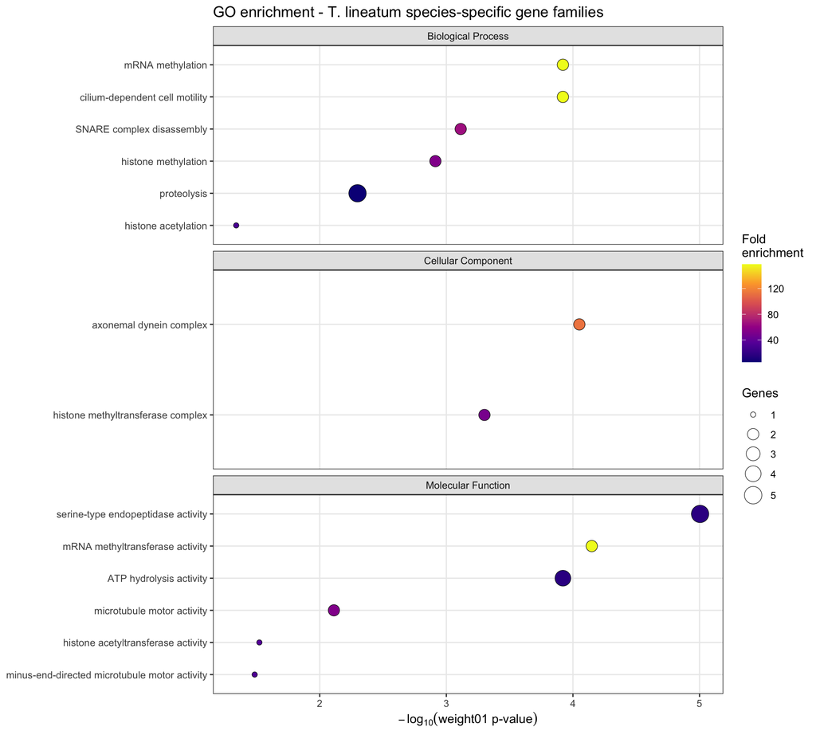

```r
if (nrow(go_sig) > 0) {
  plot_go <- go_sig %>%
    dplyr::group_by(Ontology) %>%
    dplyr::slice_min(weightFisher, n = 15) %>%
    dplyr::ungroup() %>%
    dplyr::mutate(
      Term = stringr::str_trunc(Term, 55),
      Term = forcats::fct_reorder(Term, -log10(weightFisher))
    )

  p_go <- ggplot2::ggplot(plot_go,
                          ggplot2::aes(x = -log10(weightFisher), y = Term,
                                       fill = fold_enrichment, size = Significant)) +
    ggplot2::geom_point(shape = 21, color = "black", stroke = 0.3) +
    ggplot2::facet_wrap(~ Ontology, scales = "free_y", ncol = 1,
                        labeller = ggplot2::labeller(Ontology = c(
                          BP = "Biological Process",
                          MF = "Molecular Function",
                          CC = "Cellular Component"))) +
    ggplot2::scale_fill_viridis_c(option = "plasma", name = "Fold\nenrichment") +
    ggplot2::scale_size_continuous(name = "Genes", range = c(2, 7)) +
    ggplot2::labs(x = expression(-log[10]("weight01 p-value")), y = NULL,
                  title = "GO enrichment - T. lineatum species-specific gene families") +
    ggplot2::theme_bw(base_size = 11) +
    ggplot2::theme(strip.background = ggplot2::element_rect(fill = "grey90"),
                   panel.grid.minor = ggplot2::element_blank())

  print(p_go)

  ggplot2::ggsave(file.path(out_dir, "FigureSX_GO_enrichment.png"),
                  p_go, width = 10, height = 9, dpi = 300)
  ggplot2::ggsave(file.path(out_dir, "FigureSX_GO_enrichment.pdf"),
                  p_go, width = 10, height = 9)
} else {
  cat("No significant GO terms to plot.\n")
}
```

## 7.2 Pfam: top enriched domains

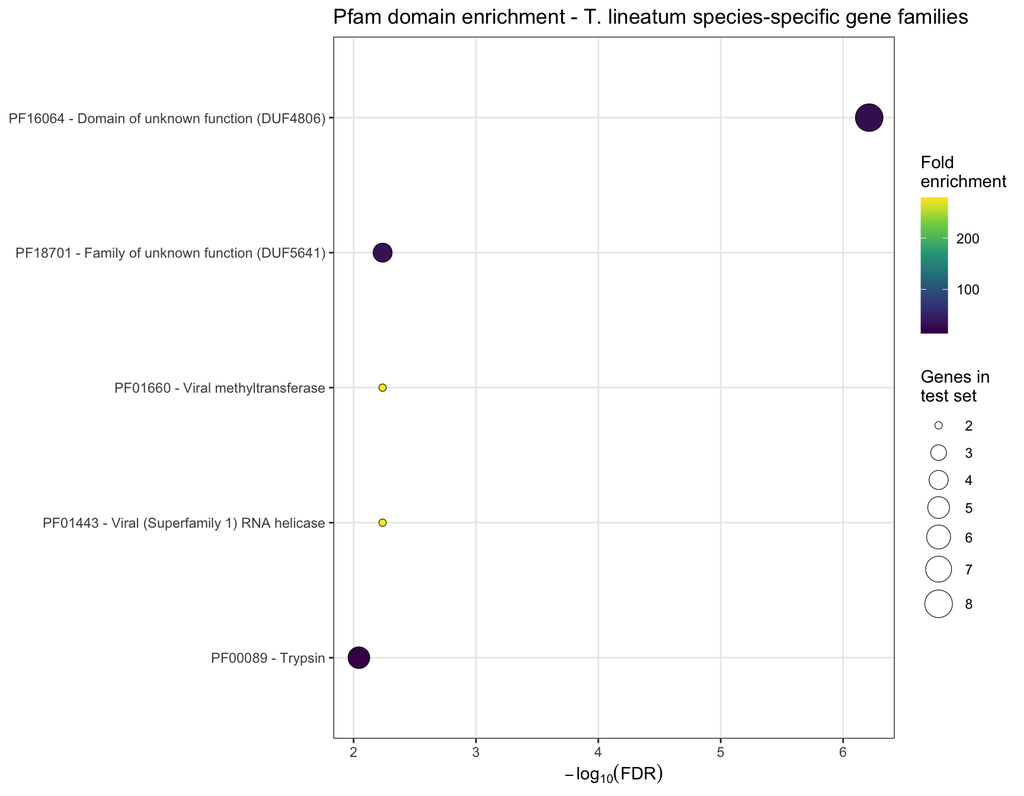

```r
if (nrow(pfam_sig) > 0) {
  plot_pfam <- pfam_sig %>%
    dplyr::slice_min(FDR, n = 20) %>%
    dplyr::mutate(
      label = paste0(sig_acc, " - ", stringr::str_trunc(sig_desc, 45)),
      label = forcats::fct_reorder(label, -log10(FDR))
    )

  p_pfam <- ggplot2::ggplot(plot_pfam,
                            ggplot2::aes(x = -log10(FDR), y = label,
                                         fill = fold_enrichment, size = n_in_test)) +
    ggplot2::geom_point(shape = 21, color = "black", stroke = 0.3) +
    ggplot2::scale_fill_viridis_c(option = "viridis", name = "Fold\nenrichment") +
    ggplot2::scale_size_continuous(name = "Genes in\ntest set", range = c(2, 8)) +
    ggplot2::labs(x = expression(-log[10]("FDR")), y = NULL,
                  title = "Pfam domain enrichment - T. lineatum species-specific gene families") +
    ggplot2::theme_bw(base_size = 11) +
    ggplot2::theme(panel.grid.minor = ggplot2::element_blank())

  print(p_pfam)

  ggplot2::ggsave(file.path(out_dir, "FigureSX_Pfam_enrichment.png"),
                  p_pfam, width = 9, height = 7, dpi = 300)
  ggplot2::ggsave(file.path(out_dir, "FigureSX_Pfam_enrichment.pdf"),
                  p_pfam, width = 9, height = 7)
} else {
  cat("No significant Pfam domains to plot.\n")
}
```

# 8. Summary by biological category

Thematic classification useful for drafting the discussion (lines 446-448).

```r
biology_keywords <- list(
  "Detoxification / xenobiotic metabolism" = c("cytochrome P450", "P450",
      "glutathione", "GST", "UDP-glucuronosyl", "carboxylesterase",
      "epoxide", "ABC transporter"),
  "Chemoreception"                          = c("odorant", "olfactory",
      "gustatory", "chemosensory", "pheromone"),
  "Digestion / carbohydrate metabolism"     = c("glycos", "cellulase",
      "xylanase", "mannanase", "chitin", "lipase", "peptidase"),
  "Immunity / defense"                      = c("immun", "antimicrobial",
      "defensin", "toll", "serine protease inhibitor"),
  "Cuticle / structural"                    = c("cuticle", "chitin binding"),
  "Reproduction / development"              = c("vitellogenin", "yolk",
      "oogenesis", "spermatogenesis")
)

classify_term <- function(term) {
  cats <- purrr::map_chr(names(biology_keywords), function(cat) {
    if (any(stringr::str_detect(tolower(term),
                                tolower(biology_keywords[[cat]])))) cat else NA_character_
  })
  cats <- cats[!is.na(cats)]
  if (length(cats) == 0) "Other / uncharacterized" else paste(cats, collapse = "; ")
}

if (nrow(go_sig) > 0) {
  go_sig_cat <- go_sig %>%
    dplyr::mutate(Category = purrr::map_chr(Term, classify_term)) %>%
    dplyr::arrange(Category, weightFisher)
  readr::write_tsv(go_sig_cat,
                   file.path(out_dir, "S_TableX_GO_enrichment_categorized.tsv"))
  cat("=== Significant GO terms by biological category ===\n")
  go_sig_cat %>% dplyr::count(Category, sort = TRUE) %>% print()
}
```

```
=== Significant GO terms by biological category ===
# A tibble: 2 × 2
  Category                                n
  <chr>                               <int>
1 Other / uncharacterized                13
2 Digestion / carbohydrate metabolism     1
```

```r
if (nrow(pfam_sig) > 0) {
  pfam_sig_cat <- pfam_sig %>%
    dplyr::mutate(Category = purrr::map_chr(sig_desc, classify_term)) %>%
    dplyr::arrange(Category, FDR)
  readr::write_tsv(pfam_sig_cat,
                   file.path(out_dir, "S_TableX_Pfam_enrichment_categorized.tsv"))
  cat("\n=== Significant Pfam domains by biological category ===\n")
  pfam_sig_cat %>% dplyr::count(Category, sort = TRUE) %>% print()
}
```

```
=== Significant Pfam domains by biological category ===
# A tibble: 1 × 2
  Category                    n
  <chr>                   <int>
1 Other / uncharacterized     5
```

# 9. Final metrics for the manuscript

```r
cat("===== SUMMARY FOR LINES 446-448 =====\n\n")
```

```
===== SUMMARY FOR LINES 446-448 =====
```

```r
cat("Species-specific orthogroups:      ", nrow(og_specific), "\n")
```

```
Species-specific orthogroups:       73
```

```r
cat("Tlin genes in these orthogroups:   ", length(specific_genes), "\n")
```

```
Tlin genes in these orthogroups:    228
```

```r
cat("  With InterProScan annotation:    ",
    sum(specific_genes %in% ipr$protein_id),
    sprintf(" (%.1f%%)\n",
            100 * sum(specific_genes %in% ipr$protein_id) / length(specific_genes)))
```

```
  With InterProScan annotation:     42  (18.4%)
```

```r
cat("  With GO term assigned:           ",
    sum(specific_genes %in% names(gene2GO)),
    sprintf(" (%.1f%%)\n",
            100 * sum(specific_genes %in% names(gene2GO)) / length(specific_genes)))
```

```
  With GO term assigned:            17  (7.5%)
```

```r
cat("\n")
```

```r
cat("Significant GO BP terms:           ", sum(go_sig$Ontology == "BP"), "\n")
```

```
Significant GO BP terms:            6
```

```r
cat("Significant GO MF terms:           ", sum(go_sig$Ontology == "MF"), "\n")
```

```
Significant GO MF terms:            6
```

```r
cat("Significant GO CC terms:           ", sum(go_sig$Ontology == "CC"), "\n")
```

```
Significant GO CC terms:            2
```

```r
cat("Significant Pfam domains:          ", nrow(pfam_sig), "\n")
```

```
Significant Pfam domains:           5
```